# Regression with categorical variables

## Packages for this section

```r
library(tidyverse)
library(broom)
```

## The pigs revisited

- Recall pig feed data, after we tidied it:

```r
my_url <- "http://ritsokiguess.site/datafiles/pigs2.txt"
pigs <- read_delim(my_url, " ")
pigs
```

| pig | feed | weight |
| --- | --- | --- |
| 1 | feed1 | 60.8 |
| 2 | feed1 | 57.0 |
| 3 | feed1 | 65.0 |
| 4 | feed1 | 58.6 |
| 5 | feed1 | 61.7 |
| 1 | feed2 | 68.7 |
| 2 | feed2 | 67.7 |
| 3 | feed2 | 74.0 |
| 4 | feed2 | 66.3 |
| 5 | feed2 | 69.8 |

[output cut: 10 more lines]

## Summaries

```r
pigs %>%
  group_by(feed) %>%
  summarize(n = n(), mean_wt = mean(weight),
            sd_wt = sd(weight))
```

| feed | n | mean_wt | sd_wt |
| --- | --- | --- | --- |
| feed1 | 5 | 60.62 | 3.064637 |
| feed2 | 5 | 69.30 | 2.926602 |
| feed3 | 5 | 94.10 | 3.613170 |
| feed4 | 5 | 86.24 | 2.896204 |

## Running through `aov` and `lm`

- What happens if we run this through `lm` rather than `aov`?
- Recall `aov` first:

```r
pigs.1 <- aov(weight ~ feed, data = pigs)
summary(pigs.1)
```

```
            Df Sum Sq Mean Sq F value   Pr(>F)
feed         3   3521  1173.5   119.1 3.72e-11 ***
Residuals   16    158     9.9
---
Signif. codes:  0 '***' 0.001 '**' 0.01 '*' 0.05 '.' 0.1 ' ' 1
```

## and now `lm`

```r
pigs.2 <- lm(weight ~ feed, data = pigs)
summary(pigs.2)
```

```
Call:
lm(formula = weight ~ feed, data = pigs)

Residuals:
   Min     1Q Median     3Q    Max
-3.900 -2.025 -0.570  1.845  5.000

Coefficients:
            Estimate Std. Error t value Pr(>|t|)
(Intercept)   60.620      1.404  43.190  < 2e-16 ***
feedfeed2      8.680      1.985   4.373 0.000473 ***
feedfeed3     33.480      1.985  16.867 1.30e-11 ***
feedfeed4     25.620      1.985  12.907 7.11e-10 ***
---
Signif. codes:  0 '***' 0.001 '**' 0.01 '*' 0.05 '.' 0.1 ' ' 1

Residual standard error: 3.138 on 16 degrees of freedom
Multiple R-squared:  0.9572,    Adjusted R-squared:  0.9491
F-statistic: 119.1 on 3 and 16 DF,  p-value: 3.72e-11
```

```r
tidy(pigs.2)
```

| term | estimate | std.error | statistic | p.value |
| --- | --- | --- | --- | --- |
| (Intercept) | 60.62 | 1.403567 | 43.189962 | 5.393957e-18 |
| feedfeed2 | 8.68 | 1.984943 | 4.372921 | 4.731212e-04 |
| feedfeed3 | 33.48 | 1.984943 | 16.866980 | 1.299852e-11 |
| feedfeed4 | 25.62 | 1.984943 | 12.907170 | 7.108367e-10 |

```r
glance(pigs.2)
```

| r.squared | adj.r.squared | sigma | statistic | p.value | df | logLik | AIC | BIC | deviance | df.residual | nobs |
| --- | --- | --- | --- | --- | --- | --- | --- | --- | --- | --- | --- |
| 0.9571521 | 0.9491181 | 3.138471 | 119.1379 | 3.720075e-11 | 3 | -49.02205 | 108.0441 | 113.0228 | 157.6 | 16 | 20 |

## Understanding those slopes

- Get one slope for each category of categorical variable feed, except for first.
- feed1 treated as “baseline”, others measured relative to that.
- Thus prediction for feed 1 is intercept, 60.62 (mean weight for feed 1).
- Prediction for feed 2 is 60.62 + 8.68 = 69.30 (mean weight for feed 2).
- Or, mean weight for feed 2 is 8.68 bigger than for feed 1.
- Mean weight for feed 3 is 33.48 bigger than for feed 1.
- Slopes can be negative, if mean for a feed had been smaller than for feed 1.

## Reproducing the ANOVA

- Pass the fitted model object into `anova`:

```r
anova(pigs.2)
```

|  | Df | Sum Sq | Mean Sq | F value | Pr(>F) |
| --- | --- | --- | --- | --- | --- |
| feed | 3 | 3520.525 | 1173.508 | 119.1379 | 3.720075e-11 |
| Residuals | 16 | 157.600 | 9.850 | NA | NA |

- Same as before.
- But no Tukey this way:

```r
TukeyHSD(pigs.2)
```

```
Error in UseMethod("TukeyHSD"): no applicable method for 'TukeyHSD' applied to an object of class "lm"
```

## The crickets

- Male crickets rub their wings together to produce a chirping sound.
- Rate of chirping, called “pulse rate”, depends on species and possibly on temperature.
- Sample of crickets of two species’ pulse rates measured; temperature also recorded.
- Does pulse rate differ for species, especially when temperature accounted for?

## The crickets data

Read the data:

```r
my_url <- "http://ritsokiguess.site/datafiles/crickets2.csv"
crickets <- read_csv(my_url)
crickets %>% slice_sample(n = 10) # display sample of rows
```

| species | temperature | pulse_rate |
| --- | --- | --- |
| exclamationis | 24.0 | 80.4 |
| niveus | 21.0 | 58.5 |
| niveus | 21.0 | 58.9 |
| exclamationis | 20.8 | 65.1 |
| niveus | 17.2 | 44.3 |
| niveus | 18.3 | 49.6 |
| exclamationis | 26.2 | 87.5 |
| niveus | 25.9 | 76.2 |
| niveus | 20.4 | 60.0 |
| exclamationis | 26.2 | 85.8 |

## Fit model with `lm`

```r
crickets.1 <- lm(pulse_rate ~ temperature + species,
                 data = crickets)
```

## Can I remove anything? No:

```r
drop1(crickets.1, test = "F")
```

|  | Df | Sum of Sq | RSS | AIC | F value | Pr(>F) |
| --- | --- | --- | --- | --- | --- | --- |
|  | NA | NA | 89.34987 | 38.81575 | NA | NA |
| temperature | 1 | 4376.083 | 4465.43244 | 158.07416 | 1371.3541 | 2.487732e-25 |
| species | 1 | 598.004 | 687.35382 | 100.06472 | 187.3994 | 6.271533e-14 |

`drop1` is right thing to use in a regression with categorical (explanatory) variables in it: “can I remove this categorical variable *as a whole*?”

## The summary

```r
summary(crickets.1)
```

```
Call:
lm(formula = pulse_rate ~ temperature + species, data = crickets)

Residuals:
    Min      1Q  Median      3Q     Max
-3.0128 -1.1296 -0.3912  0.9650  3.7800

Coefficients:
               Estimate Std. Error t value Pr(>|t|)
(Intercept)    -7.21091    2.55094  -2.827  0.00858 **
temperature     3.60275    0.09729  37.032  < 2e-16 ***
speciesniveus -10.06529    0.73526 -13.689 6.27e-14 ***
---
Signif. codes:  0 '***' 0.001 '**' 0.01 '*' 0.05 '.' 0.1 ' ' 1

Residual standard error: 1.786 on 28 degrees of freedom
Multiple R-squared:  0.9896,    Adjusted R-squared:  0.9888
F-statistic:  1331 on 2 and 28 DF,  p-value: < 2.2e-16
```

## Conclusions

- Slope for temperature says that increasing temperature by 1 degree increases pulse rate by 3.6 (same for both species)
- Slope for `speciesniveus` says that pulse rate for `niveus` about 10 lower than that for `exclamationis` at same temperature (latter species is baseline).
- R-squared of almost 0.99 is very high, so that the prediction of pulse rate from species and temperature is very good.

## What this model is doing: a graph

- Two quantitative variables and one categorical: scatterplot with categories distinguished by colour.
- This graph seems to need a title, which I define first.

```r
t1 <- "Pulse rate against temperature for two species of crickets"
t2 <- "Temperature in degrees Celsius"
ggplot(crickets, aes(x = temperature, y = pulse_rate,
  colour = species)) +
  geom_point() + geom_smooth(method = "lm", se = FALSE) +
  ggtitle(t1, subtitle = t2) -> g
```

## The graph

```r
g
```

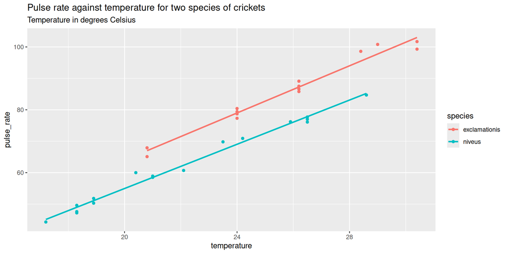

## Residuals

- We can also check residuals from this kind of model:

```r
crickets.1a <- augment(crickets.1)
crickets.1a
```

| pulse_rate | temperature | species | .fitted | .resid | .hat | .sigma | .cooksd | .std.resid |
| --- | --- | --- | --- | --- | --- | --- | --- | --- |
| 67.9 | 20.8 | exclamationis | 67.72635 | 0.1736464 | 0.14431494 | 1.818777 | 0.0006208087 | 0.10508503 |
| 65.1 | 20.8 | exclamationis | 67.72635 | -2.6263536 | 0.14431494 | 1.735136 | 0.1420144860 | -1.58938196 |
| 77.3 | 24.0 | exclamationis | 79.25516 | -1.9551628 | 0.08058651 | 1.776307 | 0.0380670566 | -1.14145698 |
| 78.7 | 24.0 | exclamationis | 79.25516 | -0.5551628 | 0.08058651 | 1.815720 | 0.0030691928 | -0.32411340 |
| 79.4 | 24.0 | exclamationis | 79.25516 | 0.1448372 | 0.08058651 | 1.818903 | 0.0002089025 | 0.08455839 |
| 80.4 | 24.0 | exclamationis | 79.25516 | 1.1448372 | 0.08058651 | 1.804566 | 0.0130518149 | 0.66837524 |
| 85.8 | 26.2 | exclamationis | 87.18122 | -1.3812191 | 0.07201029 | 1.798086 | 0.0166638845 | -0.80264418 |
| 86.6 | 26.2 | exclamationis | 87.18122 | -0.5812191 | 0.07201029 | 1.815426 | 0.0029507395 | -0.33775390 |
| 87.5 | 26.2 | exclamationis | 87.18122 | 0.3187809 | 0.07201029 | 1.818021 | 0.0008876374 | 0.18524766 |
| 89.1 | 26.2 | exclamationis | 87.18122 | 1.9187809 | 0.07201029 | 1.778289 | 0.0321589483 | 1.11502821 |

[output cut: 21 more lines]

and then…

## Residuals vs fitted

```r
ggplot(crickets.1a, aes(x = .fitted, y = .resid)) +
  geom_point()
```

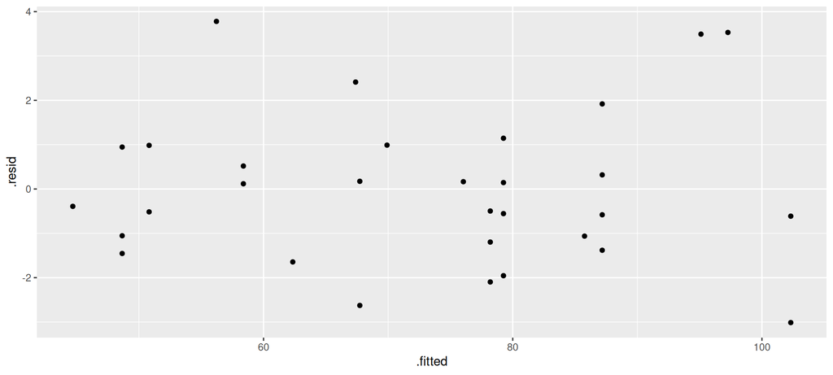

## Normal quantile plot of residuals

```r
ggplot(crickets.1a, aes(sample = .resid)) +
  stat_qq() + stat_qq_line()
```

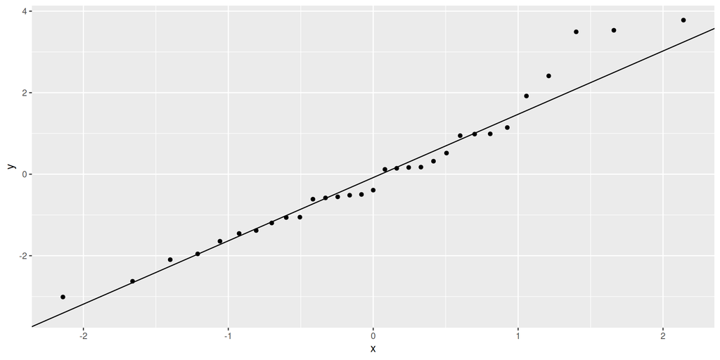

## Residuals vs. $x$’s

doesn’t work as you expect:

```r
crickets.1a %>%
  pivot_longer(temperature:species,
               names_to = "xname", values_to = "xval")
```

```
Error in `pivot_longer()`:
! Can't combine `temperature` <double> and `species` <character>.
```

## so do them separately 1/3

```r
ggplot(crickets.1a, aes(x = temperature, y = .resid)) +
  geom_point()
```

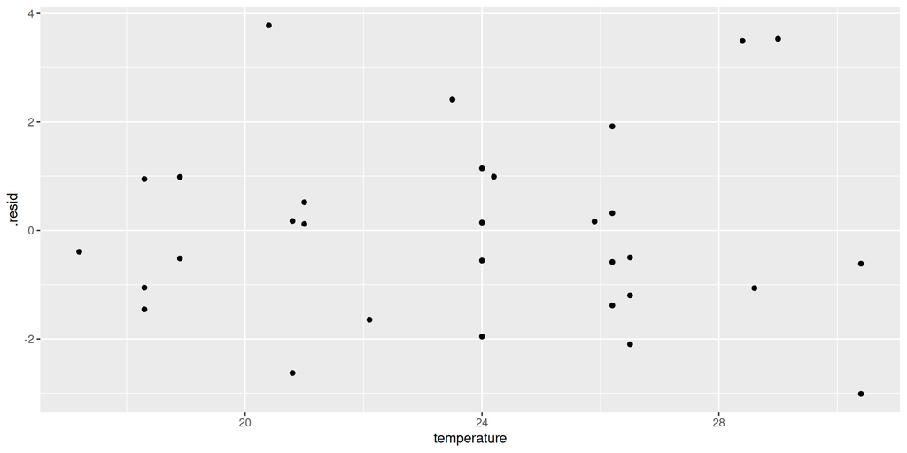

## so do them separately 2/3

```r
ggplot(crickets.1a, aes(x = species, y = .resid)) +
  geom_point()
```

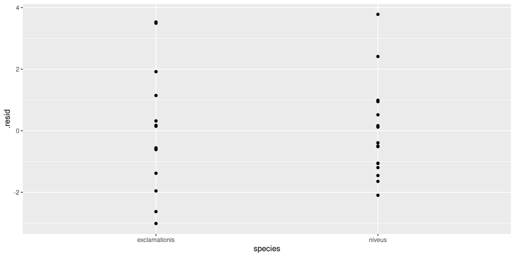

## so do them separately 3/3

or perhaps better for categorical $x$’s

```r
ggplot(crickets.1a, aes(x = species, y = .resid)) +
  geom_boxplot()
```

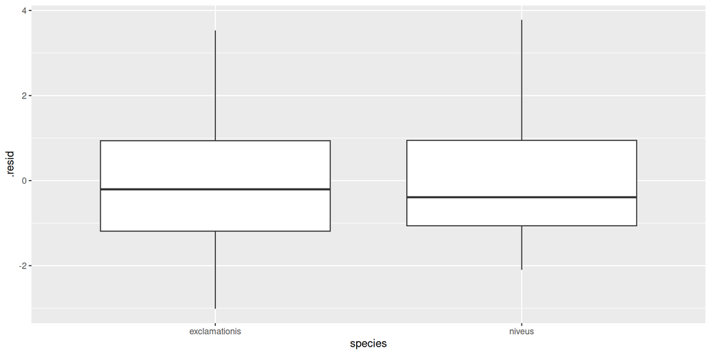